# Exploratory Data Analysis of White Wines by *Eric Perbos-Brinck*

This dataset is related to white variants of the Portuguese “Vinho Verde” wine.

Number of Instances: white wine - 4898

The inputs include objective tests (e.g. PH values) and the output is based on sensory data (median of at least 3 evaluations made by wine experts).

Each expert graded the wine quality between 0 (very bad) and 10 (very excellent).

Input variables (based on physicochemical tests):

1 - fixed acidity (tartaric acid - g / dm^3)

2 - volatile acidity (acetic acid - g / dm^3)

3 - citric acid (g / dm^3)

4 - residual sugar (g / dm^3)

5 - chlorides (sodium chloride - g / dm^3)

6 - free sulfur dioxide (mg / dm^3)

7 - total sulfur dioxide (mg / dm^3)

8 - density (g / cm^3)

9 - pH

10 - sulphates (potassium sulphate - g / dm3)

11 - alcohol (% by volume)

Output variable (based on sensory data):

12 - quality (score between 0 and 10)

https://s3.amazonaws.com/udacity-hosted-downloads/ud651/wineQualityInfo.txt

Citation Request: This dataset is public available for research. The details are described in [Cortez et al., 2009]. Please include this citation if you plan to use this database:

P. Cortez, A. Cerdeira, F. Almeida, T. Matos and J. Reis. Modeling wine preferences by data mining from physicochemical properties. In Decision Support Systems, Elsevier, 47(4):547-553. ISSN: 0167-9236.

Available at: [@Elsevier] http://dx.doi.org/10.1016/j.dss.2009.05.016 [Pre-press (pdf)] http://www3.dsi.uminho.pt/pcortez/winequality09.pdf [bib] http://www3.dsi.uminho.pt/pcortez/dss09.bib

# UNIVARIATE PLOTS SECTION

```
## [1] 4898   13
```

```
## 'data.frame':    4898 obs. of  13 variables:
##  $ X                   : int  1 2 3 4 5 6 7 8 9 10 ...
##  $ fixed.acidity       : num  7 6.3 8.1 7.2 7.2 8.1 6.2 7 6.3 8.1 ...
##  $ volatile.acidity    : num  0.27 0.3 0.28 0.23 0.23 0.28 0.32 0.27 0.3 0.22 ...
##  $ citric.acid         : num  0.36 0.34 0.4 0.32 0.32 0.4 0.16 0.36 0.34 0.43 ...
##  $ residual.sugar      : num  20.7 1.6 6.9 8.5 8.5 6.9 7 20.7 1.6 1.5 ...
##  $ chlorides           : num  0.045 0.049 0.05 0.058 0.058 0.05 0.045 0.045 0.049 0.044 ...
##  $ free.sulfur.dioxide : num  45 14 30 47 47 30 30 45 14 28 ...
##  $ total.sulfur.dioxide: num  170 132 97 186 186 97 136 170 132 129 ...
##  $ density             : num  1.001 0.994 0.995 0.996 0.996 ...
##  $ pH                  : num  3 3.3 3.26 3.19 3.19 3.26 3.18 3 3.3 3.22 ...
##  $ sulphates           : num  0.45 0.49 0.44 0.4 0.4 0.44 0.47 0.45 0.49 0.45 ...
##  $ alcohol             : num  8.8 9.5 10.1 9.9 9.9 10.1 9.6 8.8 9.5 11 ...
##  $ quality             : int  6 6 6 6 6 6 6 6 6 6 ...
```

```
##        X        fixed.acidity    volatile.acidity  citric.acid
##  Min.   :   1   Min.   : 3.800   Min.   :0.0800   Min.   :0.0000
##  1st Qu.:1225   1st Qu.: 6.300   1st Qu.:0.2100   1st Qu.:0.2700
##  Median :2450   Median : 6.800   Median :0.2600   Median :0.3200
##  Mean   :2450   Mean   : 6.855   Mean   :0.2782   Mean   :0.3342
##  3rd Qu.:3674   3rd Qu.: 7.300   3rd Qu.:0.3200   3rd Qu.:0.3900
##  Max.   :4898   Max.   :14.200   Max.   :1.1000   Max.   :1.6600
##  residual.sugar     chlorides       free.sulfur.dioxide
##  Min.   : 0.600   Min.   :0.00900   Min.   :  2.00
##  1st Qu.: 1.700   1st Qu.:0.03600   1st Qu.: 23.00
##  Median : 5.200   Median :0.04300   Median : 34.00
##  Mean   : 6.391   Mean   :0.04577   Mean   : 35.31
##  3rd Qu.: 9.900   3rd Qu.:0.05000   3rd Qu.: 46.00
##  Max.   :65.800   Max.   :0.34600   Max.   :289.00
##  total.sulfur.dioxide    density             pH          sulphates
##  Min.   :  9.0        Min.   :0.9871   Min.   :2.720   Min.   :0.2200
##  1st Qu.:108.0        1st Qu.:0.9917   1st Qu.:3.090   1st Qu.:0.4100
##  Median :134.0        Median :0.9937   Median :3.180   Median :0.4700
##  Mean   :138.4        Mean   :0.9940   Mean   :3.188   Mean   :0.4898
##  3rd Qu.:167.0        3rd Qu.:0.9961   3rd Qu.:3.280   3rd Qu.:0.5500
##  Max.   :440.0        Max.   :1.0390   Max.   :3.820   Max.   :1.0800
##     alcohol         quality
##  Min.   : 8.00   Min.   :3.000
##  1st Qu.: 9.50   1st Qu.:5.000
##  Median :10.40   Median :6.000
##  Mean   :10.51   Mean   :5.878
##  3rd Qu.:11.40   3rd Qu.:6.000
##  Max.   :14.20   Max.   :9.000
```

The variable “X”, not listed in the documentation, is a duplicate ID so we can delete it.

## Multiple histograms with raw data

A first look at the summary and the generic histograms shows that many variables have extreme outliers to the right, we may correct it in individual histograms by dropping the extreme 1% values.

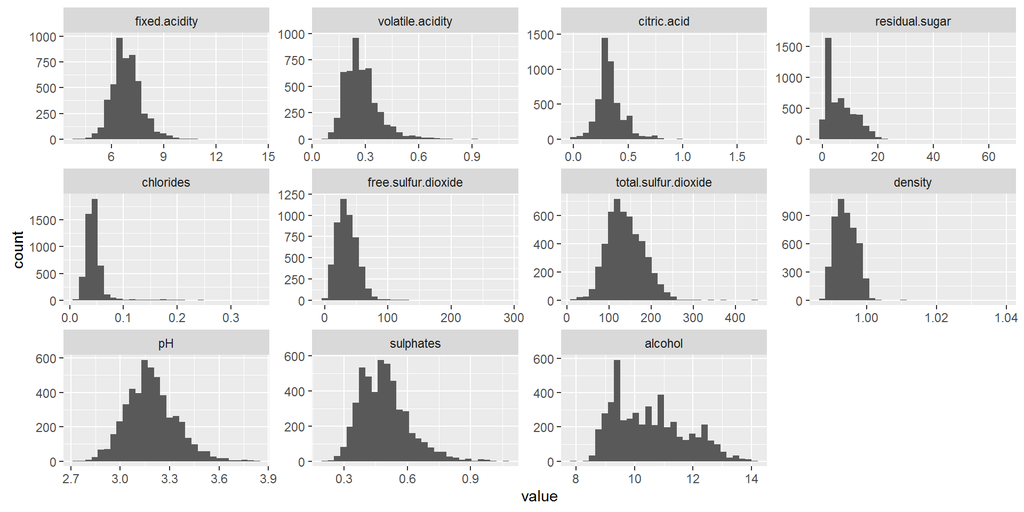

## Individual histograms with summary statistics

The individual histograms include average, median, q1 and q3 lines.

Most distributions appear normal and unimodals, with exception of “residual.sugar”.

When running a log_scale, we can see that “residual.sugar” tends to be bimodal.

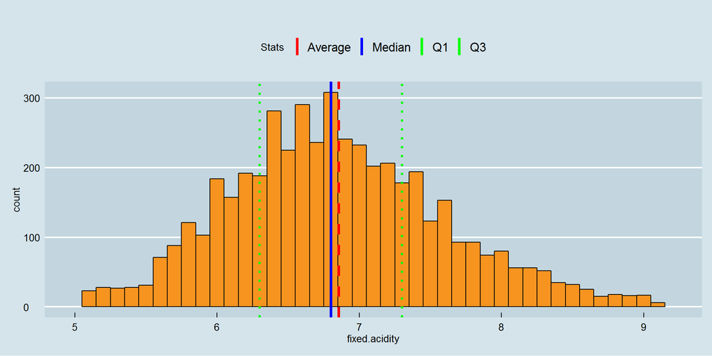

*Fixed Acidity*, with bottom and top 1% ignored: normal and unimodal distribution

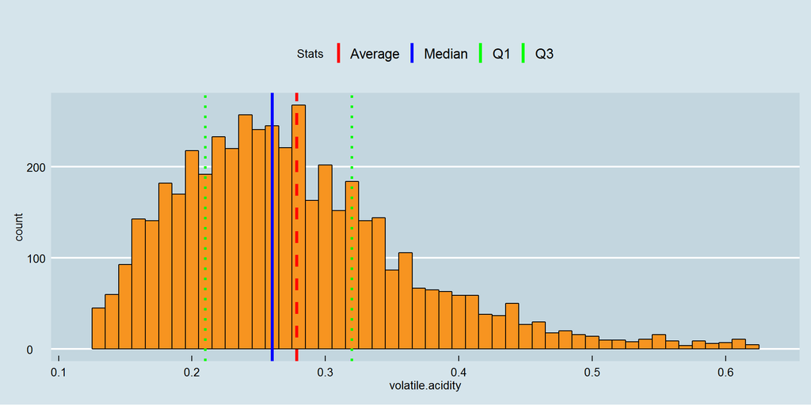

*Volatile Acidity*, with bottom and top 1% ignored: normal and unimodal distribution, skewed to the right.

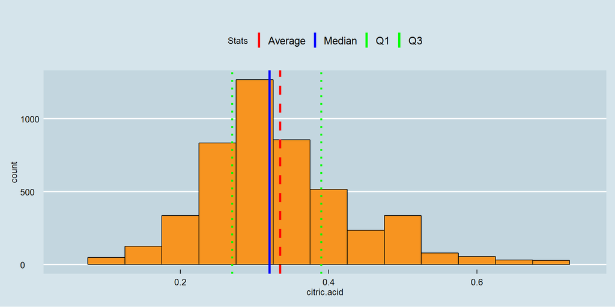

*Citric Acid*, with bottom and top 1% ignored: normal and unimodal distribution

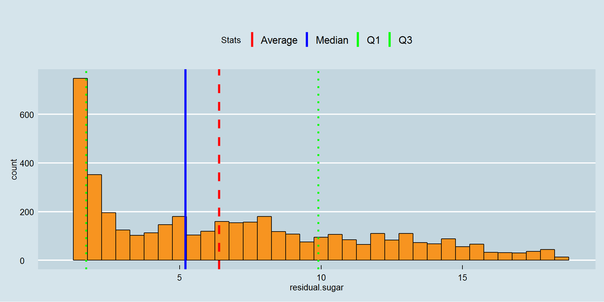

*Residual Sugar*, with bottom and top 1% ignored: highly skewed with a long tail to the right

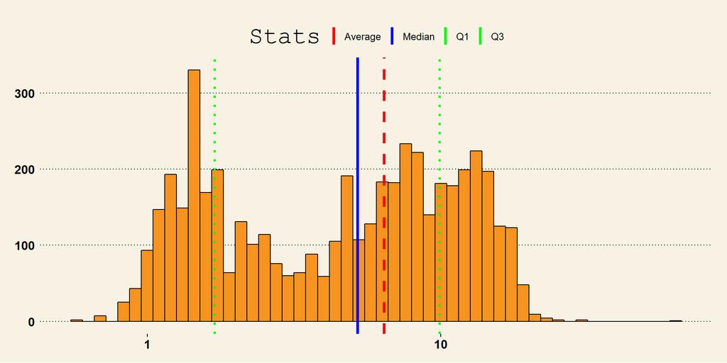

*Residual Sugar*, with bottom and top 1% ignored, log10: bimodal distribution around 1.5 and 10.0 values

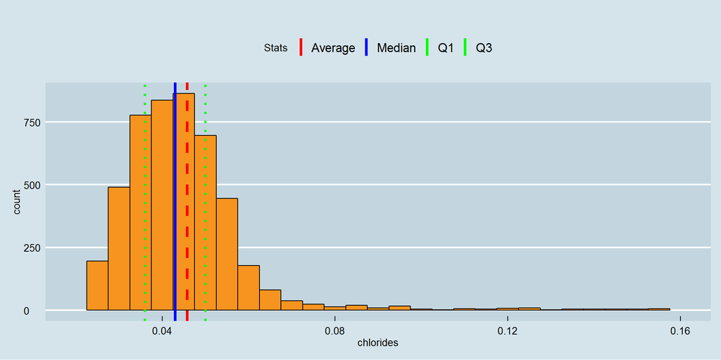

*Chlorides*, with bottom and top 1% ignored: normal and unimodal distribution, small long tail to right

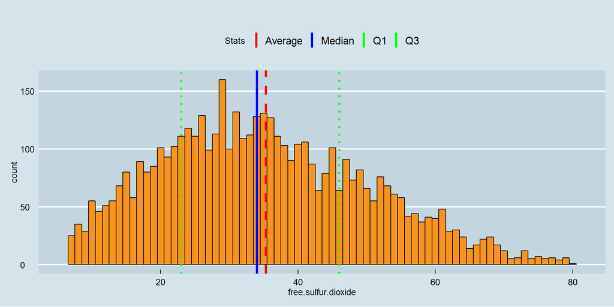

*Free Sulfur Dioxide*, with bottom and top 1% ignored: normal and unimodal distribution

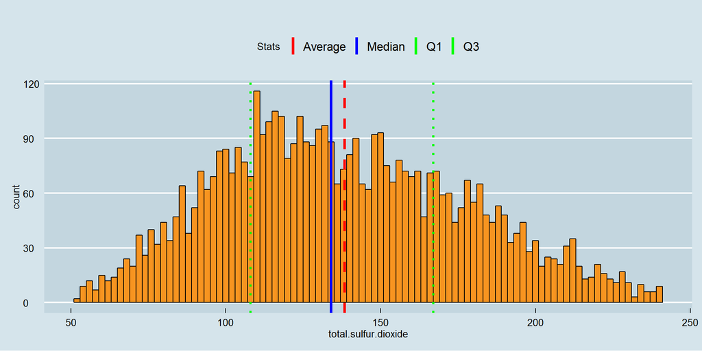

*Total Sulfur Dioxide*, with bottom and top 1% ignored: normal and unimodal distribution

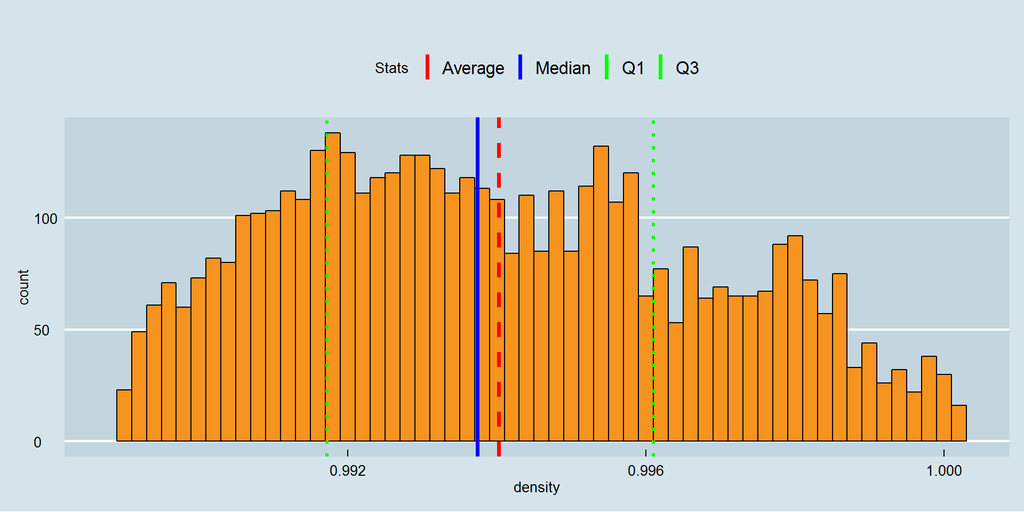

*Density*, with bottom and top 1% ignored: normal and unimodal distribution

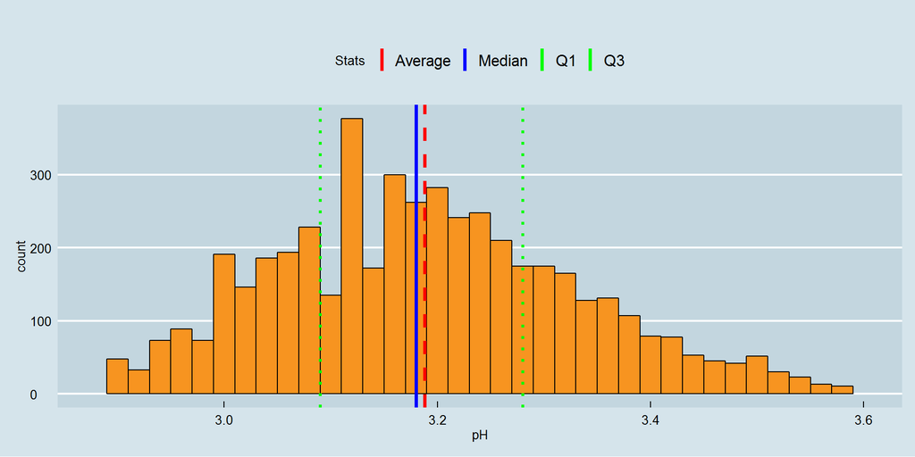

*pH*, with bottom and top 1% ignored: normal and unimodal distribution

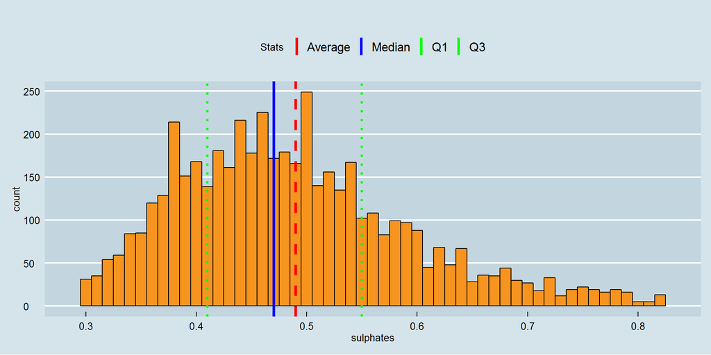

*Sulphates*, with bottom and top 1% ignored: normal and unimodal distribution

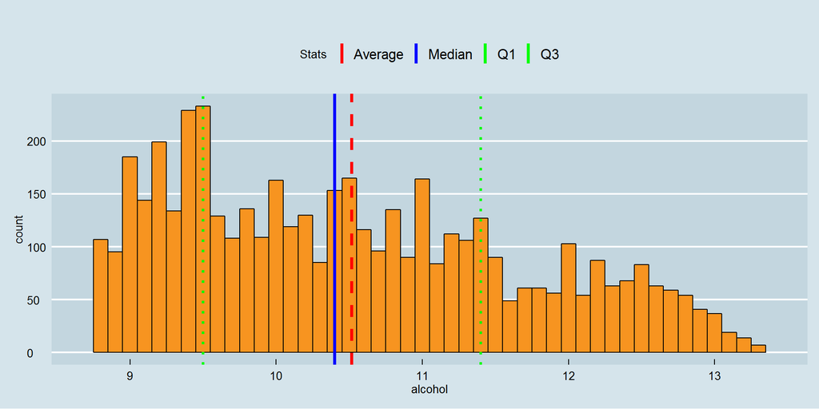

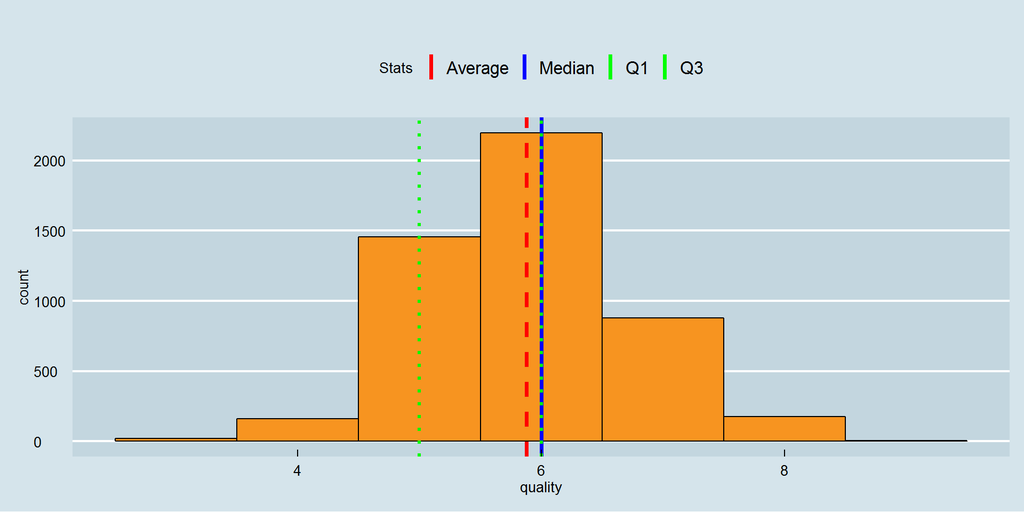

*Quality*, without bottom and top 1% ignored: normal and unimodal distribution

# Univariate Analysis

### What is the structure of your dataset?

The original dataset consists of 4898 observations of 13 variables. One variable “X” was a duplicate of each observation ID’s and was removed for the analysis.

All variables are numerically measured with the exception of Quality which is a discrete integer from 3 to 9.

### What is/are the main feature(s) of interest in your dataset?

The main feature of interest is the *Quality* variable, discretly measured by a panel of human experts.

### What other features in the dataset do you think will help support your investigation into your feature(s) of interest?

The other variables are chemical properties measured by hardware in a laboratory environment, they will serve as a framework to investigate potential relations between chemicals and *quality*.

### Did you create any new variables from existing variables in the dataset?

Beside the use of *factor(quality)*, I created a *quality.subset* variable (‘Lowest’, ‘Average’, ‘Highest’) for later use in the Multivariate Plots Section.

### Of the features you investigated, were there any unusual distributions? Did you perform any operations on the data to tidy, adjust, or change the form of the data? If so, why did you do this?

While looking at the Summary Statistics and the generic Histograms of raw data, I found that most variables suffered from extreme outliers. I chose to remove the bottom and top 1% for individual histograms, while displaying the value of Summary statistics as dotted lines for safeguard.

In the case of *residual.sugar*, I chose to create a second histogram on a *log10* scale which demonstrated a bimodal distribution.

# BIVARIATE PLOTS SECTION

We start with a pairs plot, from *psych* package, with correlations:

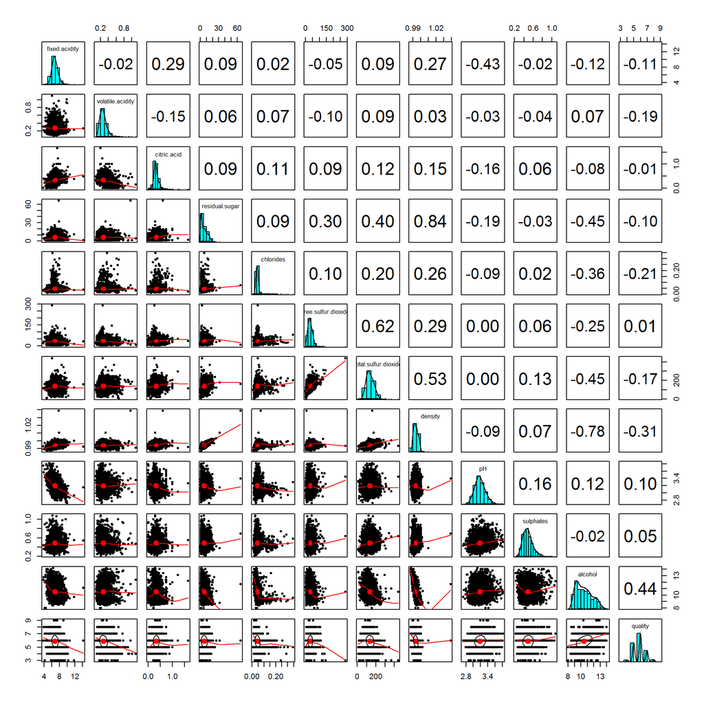

Excluding “free vs total.sulfur.dioxides” due to their direct relationship, We can see strong to moderate correlation in:

- density vs residual.sugar 0.84
- density vs alcohol -0.78
- density vs total.sulfur.dioxide 0.53
- alcohol vs total.sulfur.dioxide -0.45
- alcohol vs residual.sugar -0.45
- alcohol vs quality 0.44
- pH vs fixed.acidity -0.43

We are going to represent those via scatter plots.

## Scatter Plots

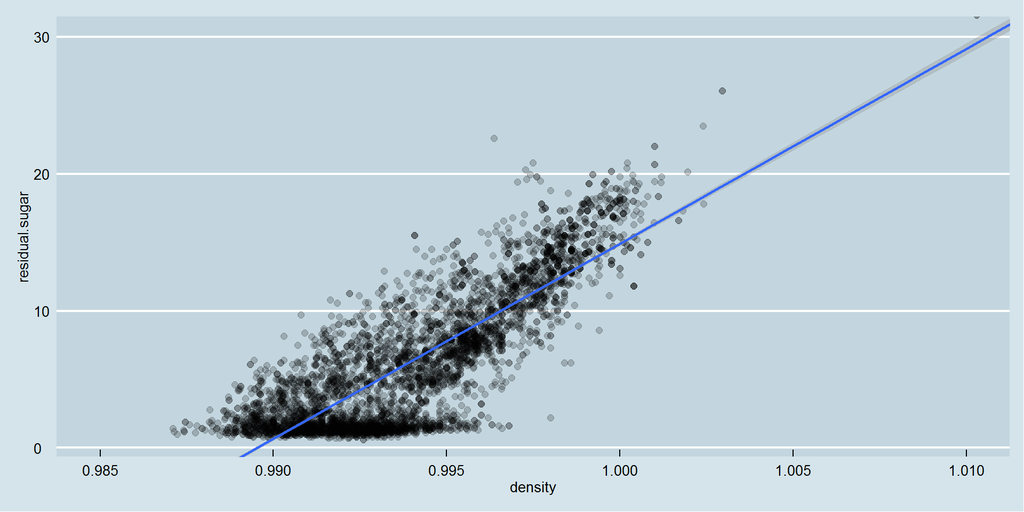

Scatter plot: *residual.sugar* vs *density*

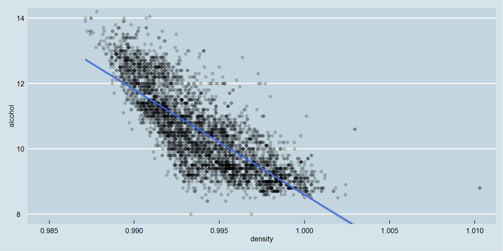

Scatter plot: *alcohol* vs *density*

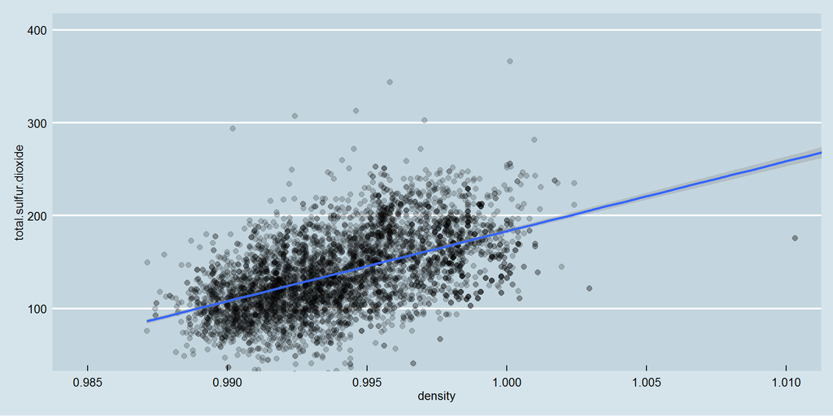

Scatter plot: *total.sulfur.dioxide* vs *density*

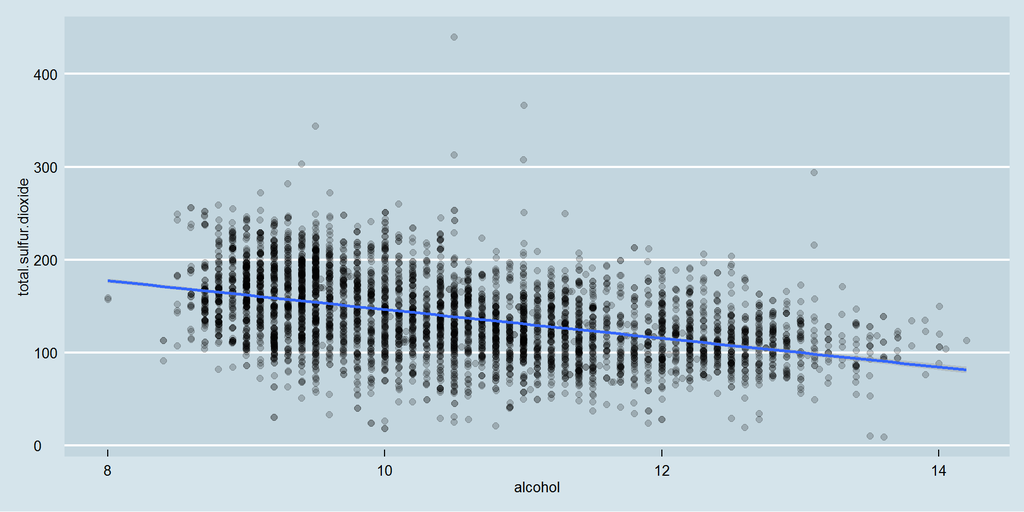

Scatter plot: *total.sulfur.dioxide* vs *alcohol*

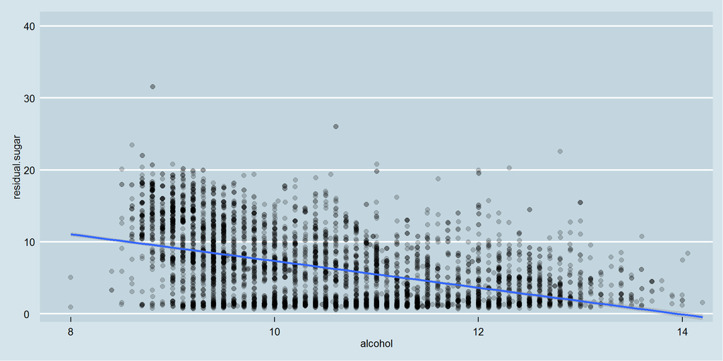

Scatter plot: *residual.sugar* vs *alcohol*

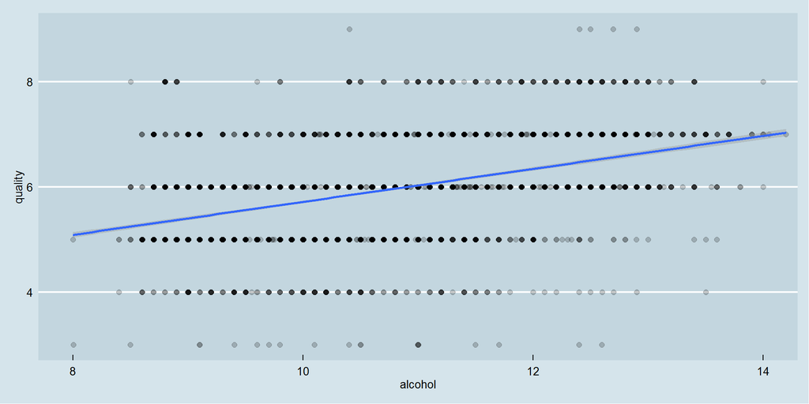

Scatter plot: *quality* vs *alcohol*

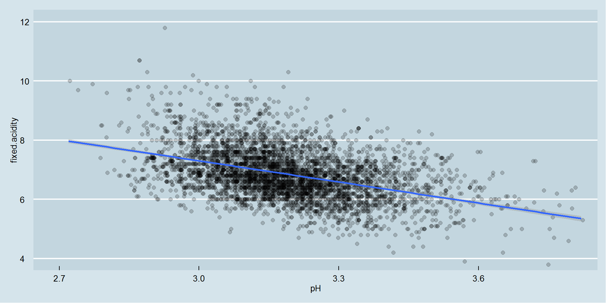

Scatter plot: *fixed.acidity* vs *pH*

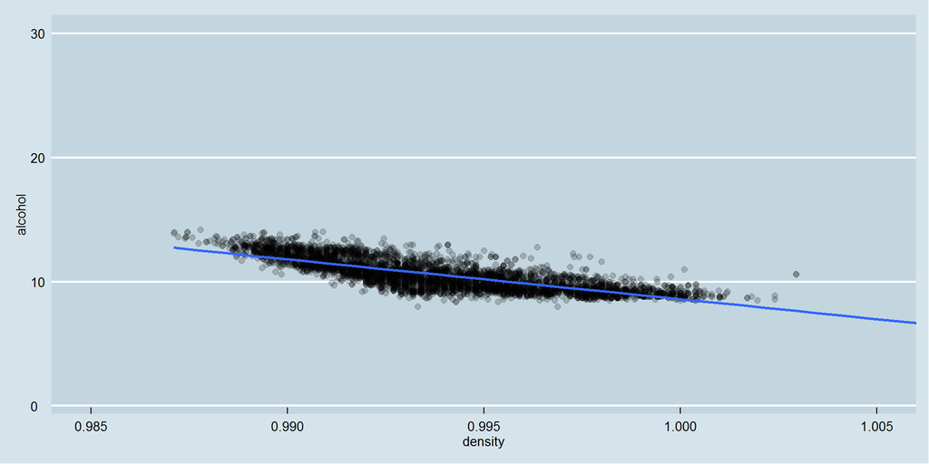

Scatter plot: *alcohol* vs *density*

## BOX PLOTS

As *Quality* is the main feature of interest in the dataset, I chose to dedicate a whole serie of Box Plots to it vs the other variables. Maybe this could reveal some insight.

But in most cases, apart from some diminishing standard deviation as quality rises, little was revealed.

Except in one case: *quality* vs *alcohol*, which showed that from *Quality=6* and above, there was a clear increase of *alcohol* levels.

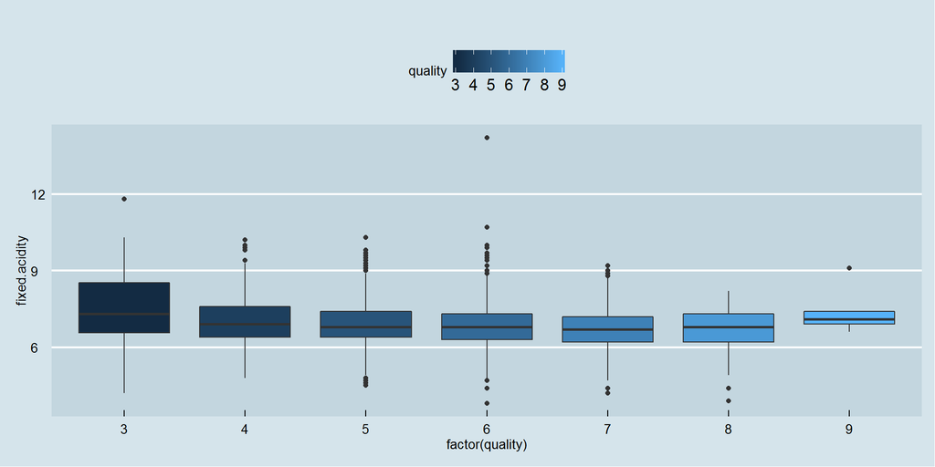

Box plot: *fixed.acidity* per *quality* grade

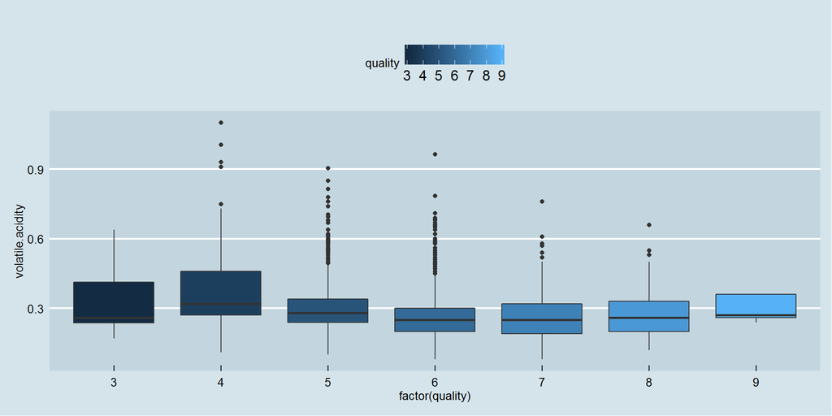

Box plot: *volatile.acidity* per *quality* grade

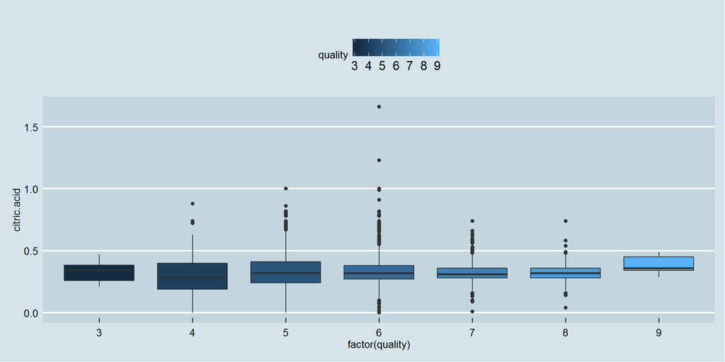

Box plot: *citric.acid* per *quality* grade

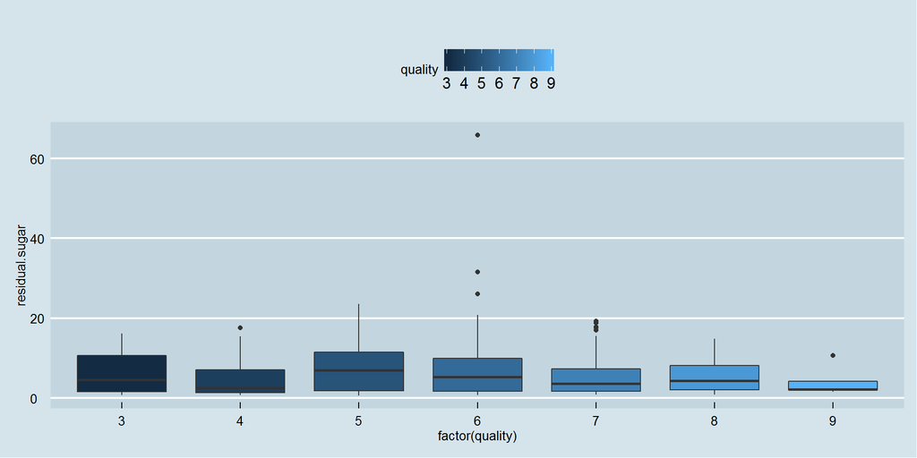

Box plot: *residual.sugar* per *quality* grade

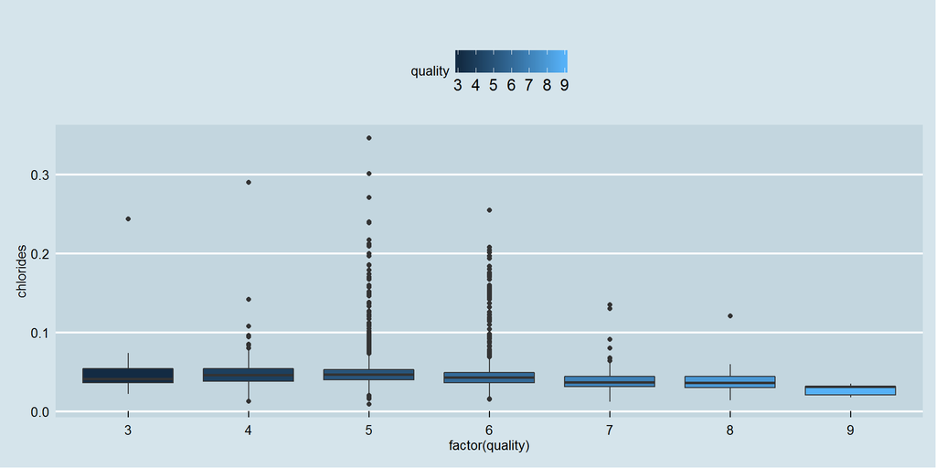

Box plot: *chlorides* per *quality* grade